# Market Timing?

[@Zhongfang Yuan(Harold)](https://space.bilibili.com/629573485)

## Don't worry, I will walk you through this topic during tutorial to show you something that is a little bit advanced.

## You needn't nor should you understand this material without coming to the tutoriol; Nor need you worry about this as this would not have 'anything' to do with your homework or project.

## However, if you do come to the tutorial, I 'promise' you would understand it and get somthing out of it.

[figure not shown]

## And by praticing, you will get there.

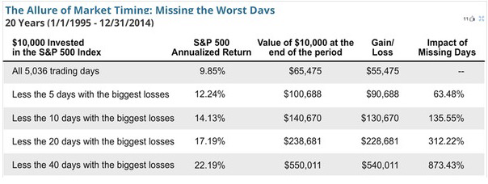

# 我们应该怎么做到低买高卖呢？

```python
import pandas as pd
import numpy as np
from scipy.stats import percentileofscore

# 读取 .pkl 文件
riskfree = pd.read_excel('中国_10年期国债收益率.xlsx', names=['date', 'interest'])
riskfree = riskfree.drop(0).reset_index()
riskfree['date'] = pd.to_datetime(riskfree['date'])
riskfree['date'] = riskfree['date'].dt.strftime('%Y%m%d')
closeprice = pd.read_pickle('IndexQuote_ClosePrice.txt')
closeprice_500 = closeprice['000905.SH'].loc['20181030':'20221129']
contents_000905  = pd.read_pickle('IndexComponent_000905.txt')
contents_000905 = contents_000905.sort_index()
data = pd.read_pickle('Example.pkl')
grouped_df = data.groupby('S_INFO_WINDCODE')
```

```python
trade_date_list_000905 = list(contents_000905.index)
start_date = '20110101'
end_date = '20230531'
```

```python
data.info()
```

```
<class 'pandas.core.frame.DataFrame'>
Index: 7440297 entries, 13352774 to 20923594
Data columns (total 36 columns):
 #   Column                       Dtype
---  ------                       -----
 0   S_INFO_WINDCODE              object
 1   TRADE_DT                     object
 2   CRNCY_CODE                   object
 3   S_VAL_MV                     float64
 4   S_DQ_MV                      float64
 5   S_PQ_HIGH_52W_               float64
 6   S_PQ_LOW_52W_                float64
 7   S_VAL_PE                     float64
 8   S_VAL_PB_NEW                 float64
 9   S_VAL_PE_TTM                 float64
```

[output cut: 28 more lines]

```python
data.describe()
```

|  | S_VAL_MV | S_DQ_MV | S_PQ_HIGH_52W_ | S_PQ_LOW_52W_ | S_VAL_PE | S_VAL_PB_NEW | S_VAL_PE_TTM | S_VAL_PCF_OCF | S_VAL_PCF_OCFTTM | S_VAL_PCF_NCF | ... | NET_PROFIT_PARENT_COMP_LYR | NET_ASSETS_TODAY | NET_CASH_FLOWS_OPER_ACT_TTM | NET_CASH_FLOWS_OPER_ACT_LYR | OPER_REV_TTM | OPER_REV_LYR | NET_INCR_CASH_CASH_EQU_TTM | NET_INCR_CASH_CASH_EQU_LYR | UP_DOWN_LIMIT_STATUS | LOWEST_HIGHEST_STATUS |
| --- | --- | --- | --- | --- | --- | --- | --- | --- | --- | --- | --- | --- | --- | --- | --- | --- | --- | --- | --- | --- | --- |
| count | 7.414597e+06 | 7.412984e+06 | 7.419638e+06 | 7.419638e+06 | 6.607488e+06 | 7.359216e+06 | 6.324379e+06 | 5.974179e+06 | 5.820714e+06 | 4.258144e+06 | ... | 7.440264e+06 | 7.440274e+06 | 7.440292e+06 | 7.440252e+06 | 7.440075e+06 | 7.439053e+06 | 7.440292e+06 | 7.440226e+06 | 4.828056e+06 | 4.828056e+06 |
| mean | 1.792854e+06 | 1.323146e+06 | 3.085247e+01 | 1.363695e+01 | 7.416931e+01 | 4.687822e+00 | 1.471560e+02 | 1.015566e+02 | 1.409974e+02 | 2.991985e+02 | ... | 9.304269e+08 | 9.935342e+09 | 1.614321e+09 | 1.469931e+09 | 1.255073e+10 | 1.187498e+10 | 3.998338e+08 | 3.132020e+08 | 1.024636e-02 | -1.104171e-03 |
| std | 7.543314e+06 | 5.788385e+06 | 5.951581e+01 | 2.621093e+01 | 1.676892e+02 | 5.699452e+01 | 1.040643e+04 | 1.716759e+03 | 5.749037e+03 | 5.532242e+03 | ... | 8.809091e+09 | 7.434932e+10 | 2.545791e+10 | 2.370133e+10 | 7.808415e+10 | 7.485263e+10 | 1.194247e+10 | 1.047536e+10 | 1.580299e-01 | 1.255413e-01 |
| min | 0.000000e+00 | 0.000000e+00 | 0.000000e+00 | 0.000000e+00 | 0.000000e+00 | 0.000000e+00 | 0.000000e+00 | 0.000000e+00 | 0.000000e+00 | 1.500000e-02 | ... | -6.400331e+10 | -3.594115e+10 | -6.326180e+11 | -5.880090e+11 | -4.484477e+09 | -1.263922e+09 | -6.976440e+11 | -3.543650e+11 | -1.000000e+00 | -1.000000e+00 |
| 25% | 2.964120e+05 | 1.928799e+05 | 8.770000e+00 | 4.540000e+00 | 2.072630e+01 | 1.622800e+00 | 1.960770e+01 | 1.291150e+01 | 1.192350e+01 | 1.637510e+01 | ... | 4.102150e+07 | 1.006233e+09 | 1.480526e+07 | 2.316937e+07 | 7.425722e+08 | 7.073919e+08 | -8.923378e+07 | -8.255240e+07 | 0.000000e+00 | 0.000000e+00 |
| 50% | 5.205310e+05 | 3.760244e+05 | 1.599000e+01 | 7.810000e+00 | 3.584230e+01 | 2.556200e+00 | 3.327060e+01 | 2.635970e+01 | 2.488850e+01 | 3.880890e+01 | ... | 1.188143e+08 | 2.091955e+09 | 1.335563e+08 | 1.336121e+08 | 1.857817e+09 | 1.765170e+09 | 1.857598e+07 | 2.214119e+07 | 0.000000e+00 | 0.000000e+00 |
| 75% | 1.175661e+06 | 8.642532e+05 | 3.230000e+01 | 1.460000e+01 | 6.748972e+01 | 4.135100e+00 | 5.988240e+01 | 5.663630e+01 | 5.367890e+01 | 1.021428e+02 | ... | 3.712262e+08 | 4.762694e+09 | 5.128913e+08 | 4.863324e+08 | 5.291657e+09 | 5.022828e+09 | 2.056983e+08 | 2.054704e+08 | 0.000000e+00 | 0.000000e+00 |
| max | 3.267370e+08 | 3.267370e+08 | 2.627880e+03 | 1.600000e+03 | 7.967069e+03 | 9.763407e+03 | 2.653832e+06 | 6.326010e+05 | 1.239265e+06 | 5.998500e+05 | ... | 3.483380e+11 | 3.055520e+12 | 1.706747e+12 | 1.557616e+12 | 3.190856e+12 | 2.966193e+12 | 8.373970e+11 | 7.298480e+11 | 1.000000e+00 | 1.000000e+00 |

8 rows × 33 columns

```python
data.columns
```

```
Index(['S_INFO_WINDCODE', 'TRADE_DT', 'CRNCY_CODE', 'S_VAL_MV', 'S_DQ_MV',
       'S_PQ_HIGH_52W_', 'S_PQ_LOW_52W_', 'S_VAL_PE', 'S_VAL_PB_NEW',
       'S_VAL_PE_TTM', 'S_VAL_PCF_OCF', 'S_VAL_PCF_OCFTTM', 'S_VAL_PCF_NCF',
       'S_VAL_PCF_NCFTTM', 'S_VAL_PS', 'S_VAL_PS_TTM', 'S_DQ_TURN',
       'S_DQ_FREETURNOVER', 'TOT_SHR_TODAY', 'FLOAT_A_SHR_TODAY',
       'S_DQ_CLOSE_TODAY', 'S_PRICE_DIV_DPS', 'S_PQ_ADJHIGH_52W',
       'S_PQ_ADJLOW_52W', 'FREE_SHARES_TODAY', 'NET_PROFIT_PARENT_COMP_TTM',
       'NET_PROFIT_PARENT_COMP_LYR', 'NET_ASSETS_TODAY',
       'NET_CASH_FLOWS_OPER_ACT_TTM', 'NET_CASH_FLOWS_OPER_ACT_LYR',
       'OPER_REV_TTM', 'OPER_REV_LYR', 'NET_INCR_CASH_CASH_EQU_TTM',
       'NET_INCR_CASH_CASH_EQU_LYR', 'UP_DOWN_LIMIT_STATUS',
       'LOWEST_HIGHEST_STATUS'],
      dtype='object')
```

# #

```python
riskfree
```

|  | index | date | interest |
| --- | --- | --- | --- |
| 0 | 1 | 20150104 | 3.6405 |
| 1 | 2 | 20150105 | 3.6406 |
| 2 | 3 | 20150106 | 3.6456 |
| 3 | 4 | 20150107 | 3.6505 |
| 4 | 5 | 20150108 | 3.6457 |
| ... | ... | ... | ... |
| 2106 | 2107 | 20230613 | 2.6583 |
| 2107 | 2108 | 20230614 | 2.6353 |
| 2108 | 2109 | 20230615 | 2.6654 |
| 2109 | 2110 | 20230616 | 2.7033 |
| 2110 | 2111 | 20230619 | 2.7145 |

2111 rows × 3 columns

```python
contents_000905
```

|  | 000005.SZ | 000006.SZ | 000008.SZ | 000009.SZ | 000012.SZ | 000016.SZ | 000021.SZ | 000025.SZ | 000027.SZ | 000028.SZ | ... | 688521.SH | 688536.SH | 688538.SH | 688567.SH | 688690.SH | 688772.SH | 688777.SH | 688779.SH | 688819.SH | 689009.SH |
| --- | --- | --- | --- | --- | --- | --- | --- | --- | --- | --- | --- | --- | --- | --- | --- | --- | --- | --- | --- | --- | --- |
| 20040102 | 0 | 1 | 0 | 0 | 0 | 1 | 0 | 0 | 0 | 1 | ... | 0 | 0 | 0 | 0 | 0 | 0 | 0 | 0 | 0 | 0 |
| 20040105 | 0 | 1 | 0 | 0 | 0 | 1 | 0 | 0 | 0 | 1 | ... | 0 | 0 | 0 | 0 | 0 | 0 | 0 | 0 | 0 | 0 |
| 20040106 | 0 | 1 | 0 | 0 | 0 | 1 | 0 | 0 | 0 | 1 | ... | 0 | 0 | 0 | 0 | 0 | 0 | 0 | 0 | 0 | 0 |
| 20040107 | 0 | 1 | 0 | 0 | 0 | 1 | 0 | 0 | 0 | 1 | ... | 0 | 0 | 0 | 0 | 0 | 0 | 0 | 0 | 0 | 0 |
| 20040108 | 0 | 1 | 0 | 0 | 0 | 1 | 0 | 0 | 0 | 1 | ... | 0 | 0 | 0 | 0 | 0 | 0 | 0 | 0 | 0 | 0 |
| ... | ... | ... | ... | ... | ... | ... | ... | ... | ... | ... | ... | ... | ... | ... | ... | ... | ... | ... | ... | ... | ... |
| 20230118 | 0 | 0 | 0 | 1 | 1 | 0 | 1 | 0 | 1 | 0 | ... | 1 | 0 | 1 | 1 | 1 | 1 | 1 | 1 | 1 | 1 |
| 20230119 | 0 | 0 | 0 | 1 | 1 | 0 | 1 | 0 | 1 | 0 | ... | 1 | 0 | 1 | 1 | 1 | 1 | 1 | 1 | 1 | 1 |
| 20230120 | 0 | 0 | 0 | 1 | 1 | 0 | 1 | 0 | 1 | 0 | ... | 1 | 0 | 1 | 1 | 1 | 1 | 1 | 1 | 1 | 1 |
| 20230130 | 0 | 0 | 0 | 1 | 1 | 0 | 1 | 0 | 1 | 0 | ... | 1 | 0 | 1 | 1 | 1 | 1 | 1 | 1 | 1 | 1 |
| 20230131 | 0 | 0 | 0 | 1 | 1 | 0 | 1 | 0 | 1 | 0 | ... | 1 | 0 | 1 | 1 | 1 | 1 | 1 | 1 | 1 | 1 |

4633 rows × 1600 columns

```python
closeprice
```

|  | 000001.SH | 000016.SH | 000063.SH | 000300.SH | 000827.SH | 000852.SH | 000903.SH | 000905.SH | 000906.SH | 000913.SH | ... | HSI.HI | IBOVESPA.GI | IXIC.GI | KS11.GI | N225.GI | SENSEX.GI | SPX.GI | TWII.TW | USDX.FX | ^W5000 |
| --- | --- | --- | --- | --- | --- | --- | --- | --- | --- | --- | --- | --- | --- | --- | --- | --- | --- | --- | --- | --- | --- |
| 19500103 | NaN | NaN | NaN | NaN | NaN | NaN | NaN | NaN | NaN | NaN | ... | NaN | NaN | NaN | NaN | NaN | NaN | 16.66000 | NaN | NaN | NaN |
| 19500104 | NaN | NaN | NaN | NaN | NaN | NaN | NaN | NaN | NaN | NaN | ... | NaN | NaN | NaN | NaN | NaN | NaN | 16.85000 | NaN | NaN | NaN |
| 19500105 | NaN | NaN | NaN | NaN | NaN | NaN | NaN | NaN | NaN | NaN | ... | NaN | NaN | NaN | NaN | NaN | NaN | 16.93000 | NaN | NaN | NaN |
| 19500106 | NaN | NaN | NaN | NaN | NaN | NaN | NaN | NaN | NaN | NaN | ... | NaN | NaN | NaN | NaN | NaN | NaN | 16.98000 | NaN | NaN | NaN |
| 19500109 | NaN | NaN | NaN | NaN | NaN | NaN | NaN | NaN | NaN | NaN | ... | NaN | NaN | NaN | NaN | NaN | NaN | 17.08000 | NaN | NaN | NaN |
| ... | ... | ... | ... | ... | ... | ... | ... | ... | ... | ... | ... | ... | ... | ... | ... | ... | ... | ... | ... | ... | ... |
| 20230118 | 3224.4060 | 2810.0860 | 2950.8459 | 4130.3143 | 2244.6876 | 6613.0050 | 4018.3248 | 6151.4557 | 4464.3690 | 11646.1059 | ... | 26343.099609 | 117857.0 | 12771.110352 | 2759.820068 | 26524.789062 | 46444.179688 | 3690.01001 | 14223.089844 | 102.4052 | 39091.019531 |
| 20230119 | 3240.2794 | 2820.8067 | 2964.9399 | 4156.0077 | 2234.3433 | 6676.0803 | 4046.8916 | 6204.3261 | 4494.8031 | 11902.4637 | ... | 26343.099609 | 117857.0 | 12771.110352 | 2759.820068 | 26524.789062 | 46444.179688 | 3690.01001 | 14223.089844 | 102.0712 | 39091.019531 |
| 20230120 | 3264.8138 | 2836.8070 | 2986.4187 | 4181.5267 | 2279.2669 | 6736.8515 | 4079.3644 | 6251.4337 | 4524.0457 | 11849.8425 | ... | 26343.099609 | 117857.0 | 12771.110352 | 2759.820068 | 26524.789062 | 46444.179688 | 3690.01001 | 14223.089844 | 101.9966 | 39091.019531 |
| 20230130 | 3269.3180 | 2839.1216 | 2978.3743 | 4201.3450 | 2313.6305 | 6786.4530 | 4100.8178 | 6283.3272 | 4545.9003 | 11749.1858 | ... | 26343.099609 | 117857.0 | 12771.110352 | 2759.820068 | 26524.789062 | 46444.179688 | 3690.01001 | 14223.089844 | 102.2304 | 39091.019531 |
| 20230131 | 3255.6692 | 2807.9519 | 2963.7905 | 4156.8578 | 2317.8727 | 6805.2756 | 4062.4385 | 6289.1500 | 4510.9567 | 11446.4643 | ... | 26343.099609 | 117857.0 | 12771.110352 | 2759.820068 | 26524.789062 | 46444.179688 | 3690.01001 | 14223.089844 | 102.2304 | 39091.019531 |

19468 rows × 67 columns

最简单的因子： PB，PE，f(PB, PE) = PB * PE, f(PB, PE) = PB / PE

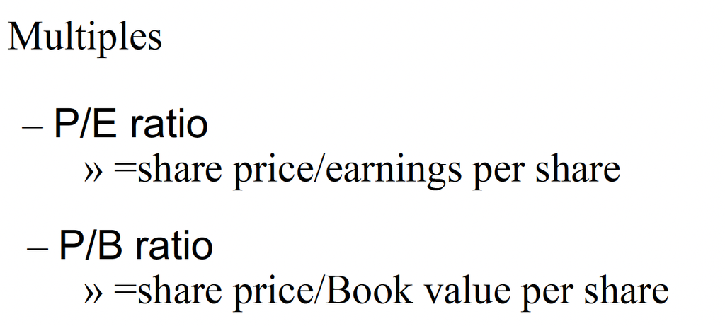

```python
contents_000905 = contents_000905.loc['20181030':'20201030']

# 这里的每一天指的是交易日
every_day_dict_500 = {}

for i in range(0,  len(contents_000905)):

    # 找出对应的那天
    date = contents_000905.iloc[i].name

    stocks = [column for column in contents_000905.columns if contents_000905.iloc[i][column]]

    market_value_sum = 0

    PB_net_value_sum = 0

    PE_NET_PROFIT_parent = 0

    for stock in stocks:

        try:
            current_stock = grouped_df.get_group(stock).sort_values('TRADE_DT')
        except:
            continue

        try:
            date_index = current_stock[current_stock['TRADE_DT'] == date].index[0]
        except:
            continue


        S_VAL_MV = current_stock.loc[date_index, 'S_VAL_MV'] * 10000

        NET_ASSETS_TODAY = current_stock.loc[date_index, 'NET_ASSETS_TODAY']

        NET_PROFIT_PARENT_COMP_TTM = current_stock.loc[date_index, 'NET_PROFIT_PARENT_COMP_TTM']

        market_value_sum += S_VAL_MV

        PB_net_value_sum += NET_ASSETS_TODAY

        PE_NET_PROFIT_parent += NET_PROFIT_PARENT_COMP_TTM

    riskfree_ = riskfree.loc[riskfree['date'] == date, 'interest'].values[0]

    PB = market_value_sum / PB_net_value_sum

    PE = market_value_sum / PE_NET_PROFIT_parent

    PBPE = (PB * PE) ** 0.5

    RISK_PREMIERE = 1/PE - riskfree_

    every_day_dict_500[date] = [PB,PE,PBPE, RISK_PREMIERE]
```

```python
# Convert the dictionary into a DataFrame
df_500 = pd.DataFrame.from_dict(every_day_dict_500, orient='index', columns=['PB', 'PE', 'PBPE', 'RISK_PREMIERE'])
```

```python
df_500
```

|  | PB | PE | PBPE | RISK_PREMIERE |
| --- | --- | --- | --- | --- |
| 20181030 | 1.553238 | 17.577739 | 5.225170 | -3.464010 |
| 20181031 | 1.577496 | 18.278784 | 5.369796 | -3.463792 |
| 20181101 | 1.587840 | 18.398638 | 5.405006 | -3.440648 |
| 20181102 | 1.638703 | 18.988664 | 5.578241 | -3.469537 |
| 20181105 | 1.638643 | 18.987659 | 5.577993 | -3.486134 |
| ... | ... | ... | ... | ... |
| 20201026 | 2.083567 | 31.352610 | 8.082405 | -3.192005 |
| 20201027 | 2.085930 | 31.400594 | 8.093173 | -3.180053 |
| 20201028 | 2.088107 | 31.344075 | 8.090103 | -3.162496 |
| 20201029 | 2.085904 | 31.225431 | 8.070517 | -3.174675 |
| 20201030 | 2.030671 | 30.282798 | 7.841837 | -3.191278 |

487 rows × 4 columns

```python
closeprice_500
```

```
20181030    4204.5424
20181031    4272.5518
20181101    4298.9837
20181102    4437.9456
20181104    4437.9456
              ...
20221123    6115.6049
20221124    6120.0659
20221125    6087.8591
20221128    6055.2843
20221129    6163.8214
Name: 000905.SH, Length: 1087, dtype: float64
```

```python
df = df_500

dfcloseprice = pd.DataFrame(closeprice)
dfcloseprice = closeprice_500
# print(dfcloseprice)
# 这里我们可以理解为工作日
DAY = 50
XDAYLATER3 = 20

bottom_thresholds = [1, 3, 5, 8, 10]
top_thresholds = [99, 97, 95, 92, 90]
bottom_signals = {}
top_signals = {}
results = {}

for i in range(DAY, len(df)):
    # end is like 20221124
    end = df.iloc[i].name

    interval_data = df.loc[:end][-DAY:]

    today_pb = df.iloc[i]['PB']
    pb_percentile = percentileofscore(interval_data['PB'], today_pb)

    today_pe = df.iloc[i]['PE']
    pe_percentile = percentileofscore(interval_data['PE'], today_pe)

    today_pbpe = df.iloc[i]['PBPE']
    pbpe_percentile = percentileofscore(interval_data['PBPE'], today_pbpe)

    today_risk_premiere = df.iloc[i]['RISK_PREMIERE']
    risk_premiere_percentile = percentileofscore(interval_data['RISK_PREMIERE'], today_risk_premiere)

    index = dfcloseprice.index.get_loc(str(end)) + XDAYLATER3

    first_price = dfcloseprice.iloc[index-20]

    try:
        # Fetch the price XDAYLATER3 days later
        end_price = dfcloseprice.iloc[index + XDAYLATER3]
    except:
        break


    # Check if any percentiles exceed the top thresholds
    for threshold in top_thresholds:
        if end_price is None:
            state = 'None'
        elif first_price > end_price:
            state = 1
        else:
            state = 0


        if pb_percentile > threshold:
            top_signals.setdefault(threshold, []).append((end, threshold, pb_percentile, today_pb, "PB", state))
            # break
        if pe_percentile > threshold:
            top_signals.setdefault(threshold, []).append((end, threshold, pe_percentile, today_pe, "PE", state))
            # break
        if pbpe_percentile > threshold:
            top_signals.setdefault(threshold, []).append((end, threshold,pbpe_percentile, today_pbpe, "PBPE", state))
            # break
        if risk_premiere_percentile > threshold:
            top_signals.setdefault(threshold, []).append((end, threshold,risk_premiere_percentile, today_risk_premiere, "RISK_PREMIERE", state))


    # Check if any percentiles fall below the bottom thresholds
    for threshold in bottom_thresholds:
        if end_price is None:
            state = 'None'
        elif first_price < end_price:
            state = 1
        else:
            state = 0

        # 观察是否触发
        if pb_percentile < threshold:
            bottom_signals.setdefault(threshold, []).append((end, threshold,pb_percentile, today_pb, "PB",state))
            # break
        if pe_percentile < threshold:
            bottom_signals.setdefault(threshold, []).append((end, threshold,pe_percentile, today_pe, "PE",state))
            # break
        if pbpe_percentile < threshold:
            bottom_signals.setdefault(threshold, []).append((end, threshold,pbpe_percentile, today_pbpe, "PBPE",state))
            # break
        if risk_premiere_percentile < threshold:
            bottom_signals.setdefault(threshold, []).append((end, threshold,risk_premiere_percentile, today_risk_premiere, "RISK_PREMIERE", state))


combined_signals = {}
combined_signals.update(top_signals)
combined_signals.update(bottom_signals)
```

```python
rows = []

for threshold, signals in combined_signals.items():
    for signal in signals:
        # try:
        row = [signal[0], signal[1], signal[2], signal[3], signal[4],signal[5]]
        # except:
        #     row = [signal[0], signal[1], signal[2], signal[3], signal[4]]
        rows.append(row)

# Define the header row
header = ['Date', 'Threshold', 'Percentile', 'Value', 'Factor','20daystate']
df_result = pd.DataFrame(rows,columns=header)
```

```python
df_result
```

|  | Date | Threshold | Percentile | Value | Factor | 20daystate |
| --- | --- | --- | --- | --- | --- | --- |
| 0 | 20190110 | 99 | 100.0 | -3.048929 | RISK_PREMIERE | 0 |
| 1 | 20190111 | 99 | 100.0 | -3.044560 | RISK_PREMIERE | 0 |
| 2 | 20190116 | 99 | 100.0 | -3.040421 | RISK_PREMIERE | 0 |
| 3 | 20190117 | 99 | 100.0 | -3.001369 | RISK_PREMIERE | 0 |
| 4 | 20190214 | 99 | 100.0 | 1.679125 | PB | 0 |
| ... | ... | ... | ... | ... | ... | ... |
| 2096 | 20201029 | 8 | 6.0 | 31.225431 | PE | 1 |
| 2097 | 20201029 | 8 | 2.0 | 8.070517 | PBPE | 1 |
| 2098 | 20201030 | 8 | 2.0 | 2.030671 | PB | 1 |
| 2099 | 20201030 | 8 | 2.0 | 30.282798 | PE | 1 |
| 2100 | 20201030 | 8 | 2.0 | 7.841837 | PBPE | 1 |

2101 rows × 6 columns

```python
grouped_df = df_result.groupby(['Threshold','Factor'])
```

```python
results = []

for group_name, group_data in grouped_df:
    percentage3 = group_data['20daystate'].astype(bool).mean() * 100
    count = len(group_data)
    results.append({'indicator': group_name, 'winning ratio': percentage3,'trigger frequency': count})

percentage_df = pd.DataFrame(results)
percentage_df = percentage_df.reset_index(drop=True)
percentage_df = percentage_df.sort_values(by= 'winning ratio', ascending= False)
```

```python
percentage_df
```

|  | indicator | winning ratio | trigger frequency |
| --- | --- | --- | --- |
| 4 | (5, PB) | 88.000000 | 25 |
| 0 | (3, PB) | 86.666667 | 15 |
| 8 | (8, PB) | 83.333333 | 36 |
| 12 | (10, PB) | 82.608696 | 46 |
| 6 | (5, PE) | 81.818182 | 11 |
| 1 | (3, PBPE) | 81.250000 | 16 |
| 2 | (3, PE) | 80.000000 | 10 |
| 5 | (5, PBPE) | 78.260870 | 23 |
| 14 | (10, PE) | 76.923077 | 26 |
| 9 | (8, PBPE) | 76.666667 | 30 |
| 10 | (8, PE) | 76.470588 | 17 |
| 13 | (10, PBPE) | 76.190476 | 42 |
| 18 | (90, PE) | 54.716981 | 106 |
| 30 | (97, PE) | 54.545455 | 77 |
| 22 | (92, PE) | 54.081633 | 98 |
| 26 | (95, PE) | 53.846154 | 91 |
| 21 | (92, PBPE) | 52.884615 | 104 |
| 34 | (99, PE) | 52.830189 | 53 |
| 17 | (90, PBPE) | 52.173913 | 115 |
| 25 | (95, PBPE) | 51.612903 | 93 |
| 29 | (97, PBPE) | 49.333333 | 75 |
| 33 | (99, PBPE) | 48.148148 | 54 |
| 16 | (90, PB) | 48.076923 | 104 |
| 7 | (5, RISK_PREMIERE) | 46.666667 | 60 |
| 15 | (10, RISK_PREMIERE) | 46.341463 | 82 |
| 11 | (8, RISK_PREMIERE) | 46.268657 | 67 |
| 20 | (92, PB) | 45.833333 | 96 |
| 3 | (3, RISK_PREMIERE) | 45.714286 | 35 |
| 24 | (95, PB) | 44.047619 | 84 |
| 28 | (97, PB) | 41.791045 | 67 |
| 32 | (99, PB) | 36.734694 | 49 |
| 19 | (90, RISK_PREMIERE) | 36.250000 | 80 |
| 23 | (92, RISK_PREMIERE) | 36.111111 | 72 |
| 27 | (95, RISK_PREMIERE) | 35.483871 | 62 |
| 35 | (99, RISK_PREMIERE) | 33.333333 | 33 |
| 31 | (97, RISK_PREMIERE) | 29.787234 | 47 |

```python
df_pd_nowadays = pd.read_excel('市场整体估值.xlsx',index_col=0)
df_pd_nowadays
```

| 序号 | 日期 | 中证500 | 中证500.1 | 中证500.2 |
| --- | --- | --- | --- | --- |
| NaN | NaN | 收盘 | 市盈率(TTM) | 市净率(LF) |
| 1.0 | 2024-01-19 00:00:00 | 5018.4332 | 20.286512 | 1.5525 |
| 2.0 | 2024-01-12 00:00:00 | 5206.178 | 21.054677 | 1.611462 |
| 3.0 | 2024-01-05 00:00:00 | 5281.8711 | 21.358787 | 1.63503 |
| 4.0 | 2023-12-29 00:00:00 | 5429.2288 | 21.836943 | 1.67265 |
| ... | ... | ... | ... | ... |
| 153.0 | 2021-01-22 00:00:00 | 6637.8052 | 29.426011 | 2.132942 |
| 154.0 | 2021-01-15 00:00:00 | 6417.5011 | 28.459617 | 2.065596 |
| 155.0 | 2021-01-08 00:00:00 | 6557.5964 | 29.050314 | 2.108869 |
| NaN | NaN | NaN | NaN | NaN |
| NaN | 数据来源：Wind | NaN | NaN | NaN |

158 rows × 4 columns

```python
np.percentile(df_pd_nowadays.iloc[1:-3,-1], 5)
```

```
1.6149401692835625
```

```python
np.percentile(df_pd_nowadays.iloc[:-3,-1], 10)
```

```
1.6351567945142265
```

[figure not shown]

结论：太低了，可以买了

## Question:

What's next?

## Question:

Does this mean anything?

# Conclusion

In this world, there are two types of investors: the first type doesn't know where the stock market is headed, and the second type doesn't know they don't know where the stock market is headed. But in reality, there is a third type of person: those who deceive and manipulate by pretending they can predict the direction of the stock market to benefit themselves.

这个世界上有两种投资人：第一种是不知道股市往哪里走的，第二种是不知道他们自己不知道股市的走向的。但是事实上还有第三种人：他们靠假装可以预测股市的走向来骗吃骗喝。